# Data 606 Final Project

Mohamed Hassan-El Serafi

2023-05-16

# Abstract

This analysis examines factors that influence an NBA basketball player’s WinShare totals. Using specific explanatory variables within the dataset, I explore the linear relationship between WinShares and each selected variable using a multiple linear regression model. Each observation in the dataset are players who were drafted between 1989 and 2021. Independent variables used include career player stats of points, rebounds, assists, field goal percentage, minutes played, plus/minus, and overall draft selection. For purposes of this analysis, players containing missing data were removed.

# Introduction

The National Basketball Association has seen a huge surge in the use of data analytics over the past 15 years. The purpose of aggregating data is to assist in making basketball decisions that will help identify players that can lead to wins and possibly a championship. Using NBA player data obtained from Kaggle, I will explore various variables to ascertain what influences a player’s WinShare. Independent variables utilized include plus/minus, points, total rebounds, assists, minutes played, overall draft pick selection, and field goal percentage.

### Part 2 - Data

```r
library(tidyverse)
library(DT)
library(GGally)
library(vtable)
```

```r
glimpse(df)
```

```
## Rows: 1,922
## Columns: 24
## $ id                        <int> 1, 2, 3, 4, 5, 6, 7, 8, 9, 10, 11, 12, 13, 1…
## $ year                      <int> 1989, 1989, 1989, 1989, 1989, 1989, 1989, 19…
## $ rank                      <int> 1, 2, 3, 4, 5, 6, 7, 8, 9, 10, 11, 12, 13, 1…
## $ overall_pick              <int> 1, 2, 3, 4, 5, 6, 7, 8, 9, 10, 11, 12, 13, 1…
## $ team                      <chr> "SAC", "LAC", "SAS", "MIA", "CHH", "CHI", "I…
## $ player                    <chr> "Pervis Ellison", "Danny Ferry", "Sean Ellio…
## $ college                   <chr> "Louisville", "Duke", "Arizona", "Michigan",…
## $ years_active              <int> 11, 13, 12, 15, 11, 8, 12, 5, 12, 10, 13, 13…
## $ games                     <int> 474, 917, 742, 1000, 672, 438, 766, 281, 687…
## $ minutes_played            <int> 11593, 18133, 24502, 34985, 15370, 7406, 174…
## $ points                    <int> 4494, 6439, 10544, 18336, 5680, 2819, 6925, …
## $ total_rebounds            <int> 3170, 2550, 3204, 4387, 3381, 1460, 2342, 13…
## $ assists                   <int> 691, 1185, 1897, 2097, 639, 387, 1769, 175, …
## $ field_goal_percentage     <dbl> 0.510, 0.446, 0.465, 0.456, 0.472, 0.478, 0.…
## $ X3_point_percentage       <dbl> 0.050, 0.393, 0.375, 0.400, 0.135, 0.235, 0.…
## $ free_throw_percentage     <dbl> 0.689, 0.840, 0.799, 0.846, 0.716, 0.707, 0.…
## $ average_minutes_played    <dbl> 24.5, 19.8, 33.0, 35.0, 22.9, 16.9, 22.8, 19…
## $ points_per_game           <dbl> 9.5, 7.0, 14.2, 18.3, 8.5, 6.4, 9.0, 7.4, 5.…
## $ average_total_rebounds    <dbl> 6.7, 2.8, 4.3, 4.4, 5.0, 3.3, 3.1, 4.9, 3.3,…
## $ average_assists           <dbl> 1.5, 1.3, 2.6, 2.1, 1.0, 0.9, 2.3, 0.6, 0.6,…
## $ win_shares                <dbl> 21.8, 34.8, 55.7, 88.7, 22.5, 10.9, 24.6, 1.…
## $ win_shares_per_48_minutes <dbl> 0.090, 0.092, 0.109, 0.122, 0.070, 0.071, 0.…
## $ box_plus_minus            <dbl> -0.5, -0.9, 0.2, 0.8, -2.9, -3.4, -0.8, -5.0…
## $ value_over_replacement    <dbl> 4.4, 4.9, 13.5, 24.9, -3.7, -2.7, 5.3, -4.0,…
```

The dataset has 1,922 observations and 24 columns/variables. Each row represents a player who was drafted in the first or second round between 1989 and 2021. Players who did not play in the NBA have missing values. For purposes of this project, I will drop those players with missing data from the dataset. The target variable is WinShares, defined as adding together Offensive Win Shares and Defensive Win Shares. This article from Basketball Reference describes how Offensive and Defensive Win Shares are respectively calculated. The independent variables used are:

**overall_pick**: Overall draft selection of each player (categorical variable) **points**: Total career points **total_rebounds**: Total career rebounds **assists**: Total career assists **field_goal_percentage**: Career field goal percentage **minutes_played**: Total career minutes played **box_plus_minus**: Measure of a player’s productivity on the court. Positive numbers indicate that the player helped increase their respective team’s lead or decrease the deficit. A minus indicates that the deficit increased or the team’s lead decreased.

### Part 3 - Exploratory Data Analysis

```r
# summary statistics
st(df)
```

Summary Statistics

| Variable | N | Mean | Std. Dev. | Min | Pctl. 25 | Pctl. 75 | Max |
| --- | --- | --- | --- | --- | --- | --- | --- |
| id | 1922 | 962 | 555 | 1 | 481 | 1442 | 1922 |
| year | 1922 | 2005 | 9.5 | 1989 | 1997 | 2013 | 2021 |
| rank | 1922 | 30 | 17 | 1 | 15 | 44 | 60 |
| overall_pick | 1922 | 30 | 17 | 1 | 15 | 44 | 60 |
| years_active | 1669 | 6.3 | 4.7 | 1 | 2 | 10 | 22 |
| games | 1669 | 348 | 325 | 1 | 72 | 584 | 1541 |
| minutes_played | 1669 | 8399 | 9846 | 0 | 838 | 13246 | 52139 |
| points | 1669 | 3580 | 4826 | 0 | 265 | 5150 | 37062 |
| total_rebounds | 1669 | 1497 | 2004 | 0 | 128 | 2139 | 15091 |
| assists | 1669 | 774 | 1285 | 0 | 46 | 910 | 12091 |
| field_goal_percentage | 1665 | 0.44 | 0.084 | 0 | 0.4 | 0.47 | 1 |
| X3_point_percentage | 1545 | 0.27 | 0.13 | 0 | 0.22 | 0.36 | 1 |
| free_throw_percentage | 1633 | 0.72 | 0.12 | 0 | 0.66 | 0.8 | 1 |
| average_minutes_played | 1669 | 18 | 8.7 | 0 | 11 | 25 | 41 |
| points_per_game | 1669 | 7.3 | 5 | 0 | 3.4 | 10 | 27 |
| average_total_rebounds | 1669 | 3.2 | 2.1 | 0 | 1.7 | 4.2 | 13 |
| average_assists | 1669 | 1.6 | 1.5 | 0 | 0.5 | 2.1 | 9.5 |
| win_shares | 1669 | 18 | 28 | -1.7 | 0.4 | 24 | 250 |
| win_shares_per_48_minutes | 1668 | 0.062 | 0.094 | -1.3 | 0.03 | 0.1 | 1.4 |
| box_plus_minus | 1668 | -2.3 | 4.1 | -52 | -3.9 | -0.3 | 51 |
| value_over_replacement | 1669 | 4.4 | 11 | -8.5 | -0.4 | 4.5 | 143 |

Along with the dependent variable `win_shares`, I will choose 7 independent variables to build a multiple linear regression model:

```r
new_df <- df %>%
  select(overall_pick, win_shares, minutes_played, points, total_rebounds, assists, box_plus_minus, field_goal_percentage)
DT::datatable(head(new_df))
```

|  | overall_pick | win_shares | minutes_played | points | total_rebounds | assists | box_plus_minus | field_goal_percentage |
| --- | --- | --- | --- | --- | --- | --- | --- | --- |
| 1 | 1 | 21.8 | 11593 | 4494 | 3170 | 691 | -0.5 | 0.51 |
| 2 | 2 | 34.8 | 18133 | 6439 | 2550 | 1185 | -0.9 | 0.446 |
| 3 | 3 | 55.7 | 24502 | 10544 | 3204 | 1897 | 0.2 | 0.465 |
| 4 | 4 | 88.7 | 34985 | 18336 | 4387 | 2097 | 0.8 | 0.456 |
| 5 | 5 | 22.5 | 15370 | 5680 | 3381 | 639 | -2.9 | 0.472 |
| 6 | 6 | 10.9 | 7406 | 2819 | 1460 | 387 | -3.4 | 0.478 |

```r
# summary statistics of dependent and independent variables
st(new_df)
```

Summary Statistics

| Variable | N | Mean | Std. Dev. | Min | Pctl. 25 | Pctl. 75 | Max |
| --- | --- | --- | --- | --- | --- | --- | --- |
| overall_pick | 1922 | 30 | 17 | 1 | 15 | 44 | 60 |
| win_shares | 1669 | 18 | 28 | -1.7 | 0.4 | 24 | 250 |
| minutes_played | 1669 | 8399 | 9846 | 0 | 838 | 13246 | 52139 |
| points | 1669 | 3580 | 4826 | 0 | 265 | 5150 | 37062 |
| total_rebounds | 1669 | 1497 | 2004 | 0 | 128 | 2139 | 15091 |
| assists | 1669 | 774 | 1285 | 0 | 46 | 910 | 12091 |
| box_plus_minus | 1668 | -2.3 | 4.1 | -52 | -3.9 | -0.3 | 51 |
| field_goal_percentage | 1665 | 0.44 | 0.084 | 0 | 0.4 | 0.47 | 1 |

Players that were drafted that do not have data are removed from the dataset:

```r
new_df <- new_df %>%
  drop_na()
```

```r
sum(is.na(new_df))
```

```
## [1] 0
```

Checking the correlation coefficients between `win_shares` and independent variables using ggpairs(). It appears that `box_plus_minus`, `field_goal_percentage`, and `overall_pick` are the only variables that don’t have correlation coefficients with other variables:

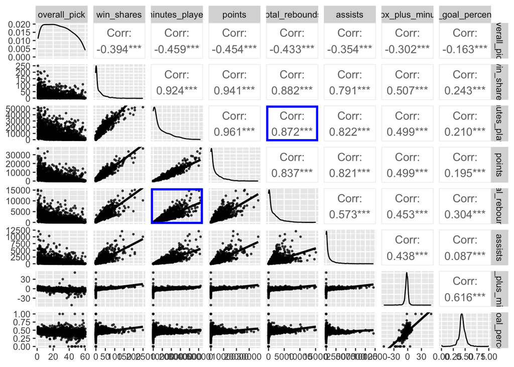

```r
p <- ggpairs(new_df[,c(1:8)], lower = list(continuous = wrap("smooth", se=FALSE, alpha = 0.7, size=0.5)))
p[5,3] <- p[5,3] + theme(panel.border = element_rect(color = 'blue', fill = NA, size = 2))
p[3,5] <- p[3,5] + theme(panel.border = element_rect(color = 'blue', fill = NA, size = 2))
p
```

Based on these results, we will only keep `box_plus_minus`, `overall_pick`, and `field_goal_percentage`, since the other variables had multicollinearity greater than 0.80.

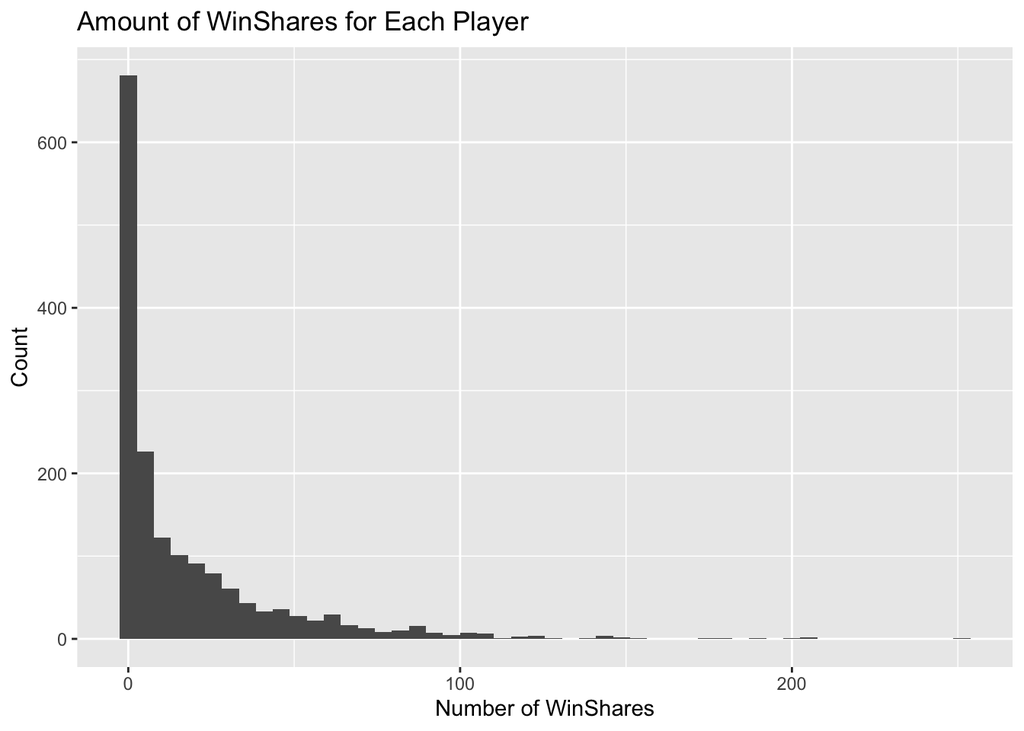

```r
new_df %>%
  ggplot(aes(x=win_shares)) +
  geom_histogram(bins = 50) +
  labs(title="Amount of WinShares for Each Player",
       x="Number of WinShares",
       y="Count")
```

To normalize the `win_shares` data, I log-transformed the variable using `log1p`. This log-transformed target variable will be used in a separate multiple linear regression model with the dependent variables. The histogram appears to show more of a normalized `win_shares` variable:

```r
# log transformation, log winshares +1
new_df$log_win_shares <- log1p(new_df$win_shares)
```

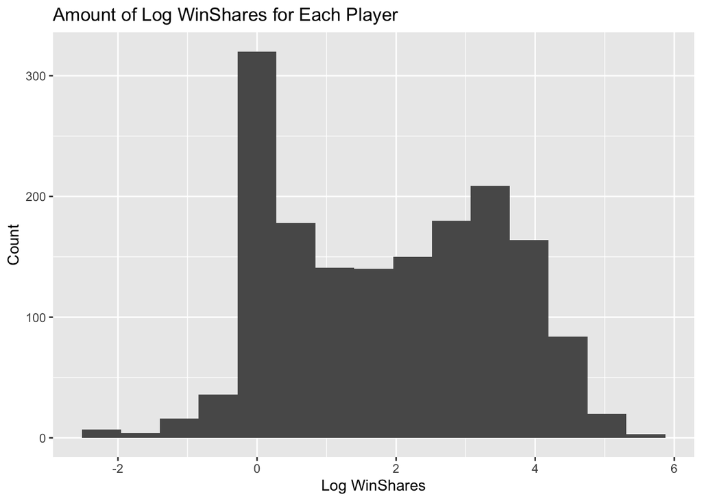

```r
new_df %>%
  ggplot(aes(x=log_win_shares)) +
  geom_histogram(bins = 15) +
  labs(title="Amount of Log WinShares for Each Player",
       x="Log WinShares",
       y="Count")
```

### Box Plus/Minus

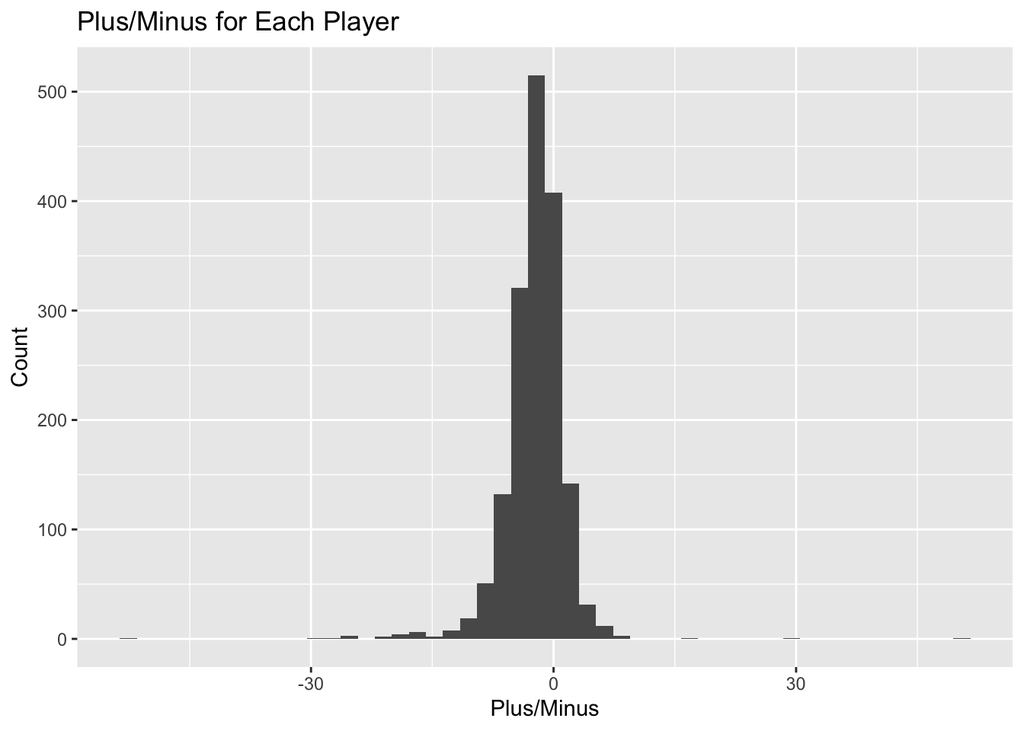

```r
new_df %>%
  ggplot(aes(box_plus_minus)) +
  geom_histogram(bins = 50) +
  labs(title="Plus/Minus for Each Player",
       x="Plus/Minus",
       y="Count")
```

### Field Goal Percentage

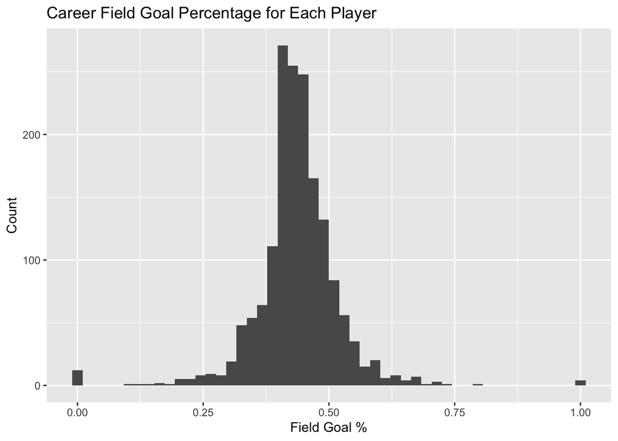

```r
new_df %>%
  ggplot(aes(field_goal_percentage)) +
  geom_histogram(bins = 50) +
  labs(title="Career Field Goal Percentage for Each Player",
       x="Field Goal %",
       y="Count")
```

### Overall Draft Pick Selection

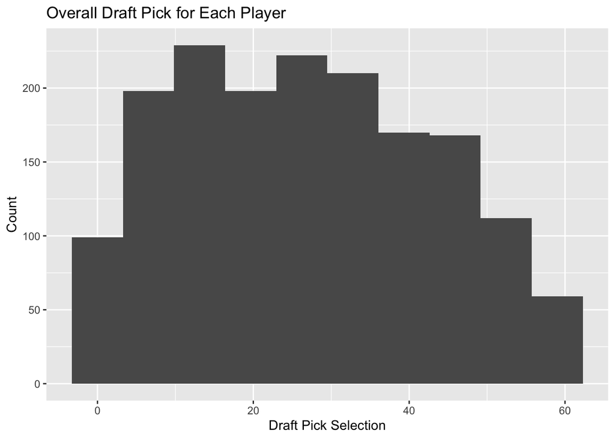

```r
new_df %>%
  ggplot(aes(overall_pick)) +
  geom_histogram(bins = 10) +
  labs(title="Overall Draft Pick for Each Player",
       x="Draft Pick Selection",
       y="Count")
```

### WinShares and Box Plus/Minus

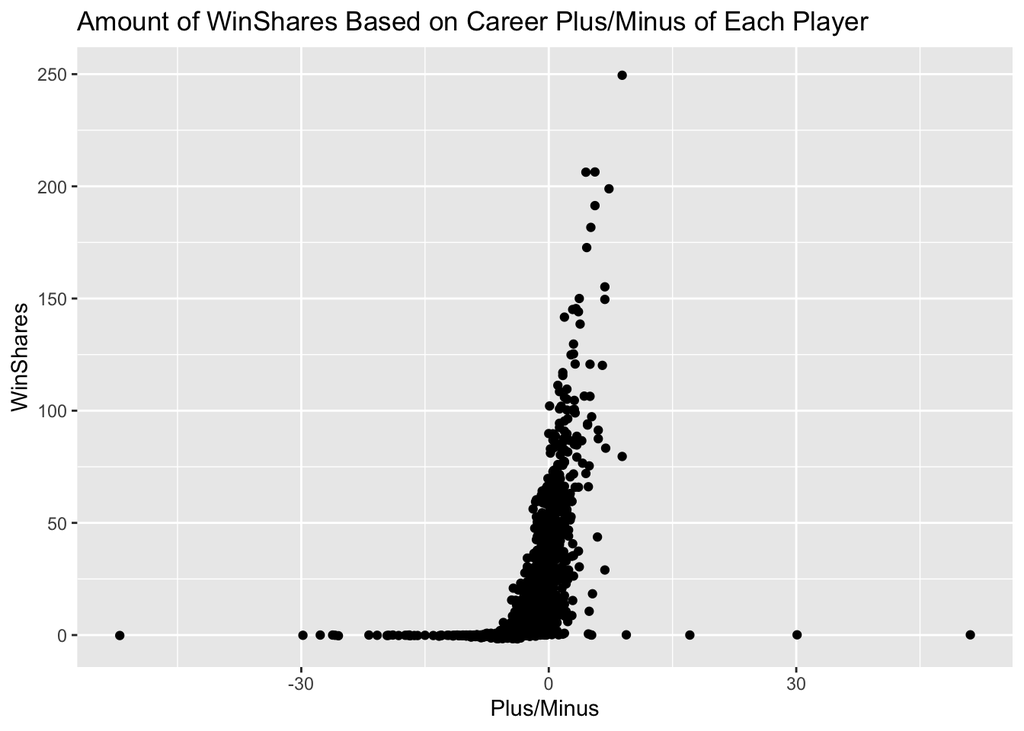

```r
new_df %>%
  ggplot(aes(box_plus_minus, win_shares, na.rm=TRUE)) +
  geom_point() +
  labs(title="Amount of WinShares Based on Career Plus/Minus of Each Player",
       x="Plus/Minus",
       y="WinShares")
```

### WinShares and Overall Draft Pick Selection

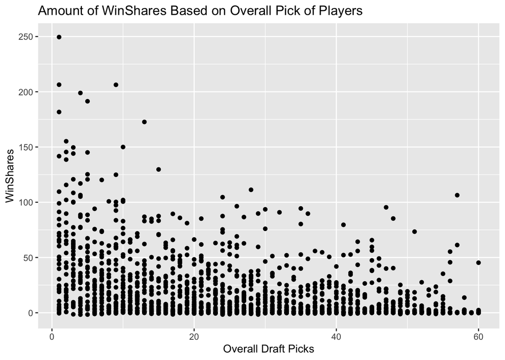

```r
new_df %>%
  ggplot(aes(overall_pick, win_shares, na.rm=TRUE)) +
  geom_point() +
  labs(title="Amount of WinShares Based on Overall Pick of Players",
       x="Overall Draft Picks",
       y="WinShares")
```

### WinShares and Field Goal Percentage

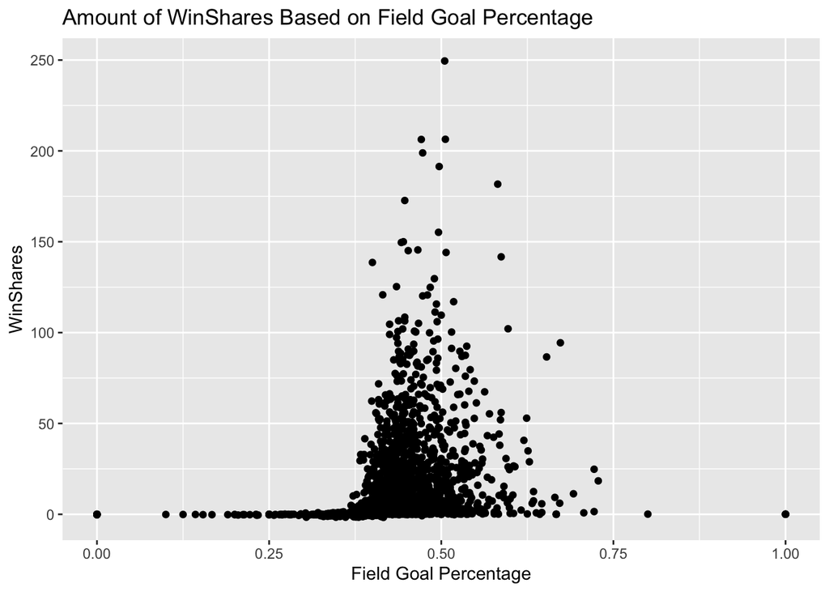

```r
new_df %>%
  ggplot(aes(field_goal_percentage, win_shares)) +
  geom_point() +
  labs(title="Amount of WinShares Based on Field Goal Percentage",
       x="Field Goal Percentage",
       y="WinShares")
```

## Part 4 - Inference

Using the original `win_shares` variable, I created a multiple linear regression model:

```r
m_initial <- lm(win_shares ~ box_plus_minus + field_goal_percentage
                + overall_pick, data = new_df)
summary(m_initial)
```

```
##
## Call:
## lm(formula = win_shares ~ box_plus_minus + field_goal_percentage +
##     overall_pick, data = new_df)
##
## Residuals:
##      Min       1Q   Median       3Q      Max
## -169.933  -12.910   -5.237    5.759  184.231
##
## Coefficients:
##                        Estimate Std. Error t value Pr(>|t|)
## (Intercept)            52.86838    4.09678  12.905  < 2e-16 ***
## box_plus_minus          3.38248    0.18220  18.565  < 2e-16 ***
## field_goal_percentage -34.14967    8.53325  -4.002 6.56e-05 ***
## overall_pick           -0.45810    0.03685 -12.432  < 2e-16 ***
## ---
## Signif. codes:  0 '***' 0.001 '**' 0.01 '*' 0.05 '.' 0.1 ' ' 1
##
## Residual standard error: 22.99 on 1661 degrees of freedom
## Multiple R-squared:  0.3275, Adjusted R-squared:  0.3263
## F-statistic: 269.6 on 3 and 1661 DF,  p-value: < 2.2e-16
```

The initial results show that the model has an Adjusted R-square of 32.63%. All 3 variables have p-values less than 0.05, and therefore show statistical significance with `win_shares`.

The following are residual plots to capture the linearity, near normal residuals, and constant variability of the model:

### Residual vs Fitted Values Plot

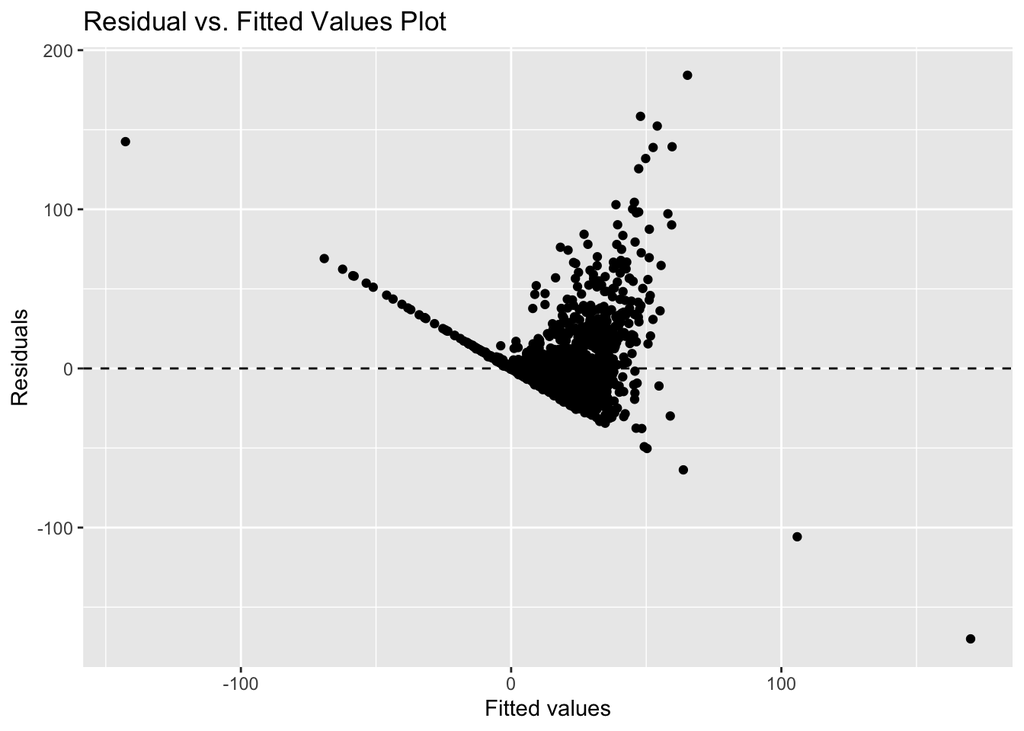

```r
ggplot(m_initial, aes(x = .fitted, y = .resid)) +
  geom_point() +
  geom_hline(yintercept = 0, linetype = "dashed") +
  labs(title="Residual vs. Fitted Values Plot") +
  xlab("Fitted values") +
  ylab("Residuals")
```

### Near Normal Residuals Histogram

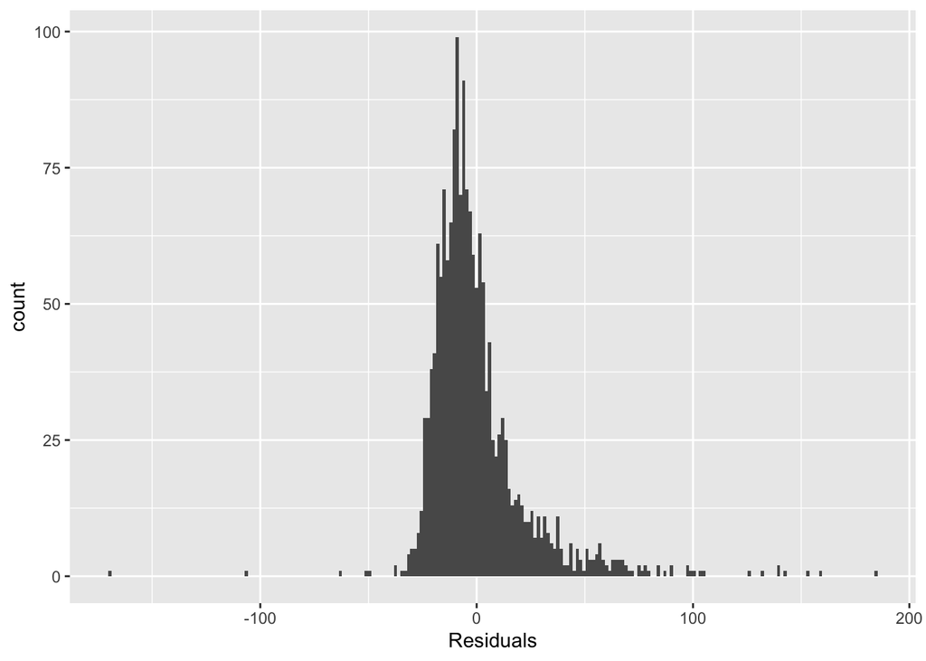

```r
ggplot(data = m_initial, aes(x = .resid)) +
  geom_histogram(binwidth = 1.5) +
  xlab("Residuals")
```

### QQ Plot

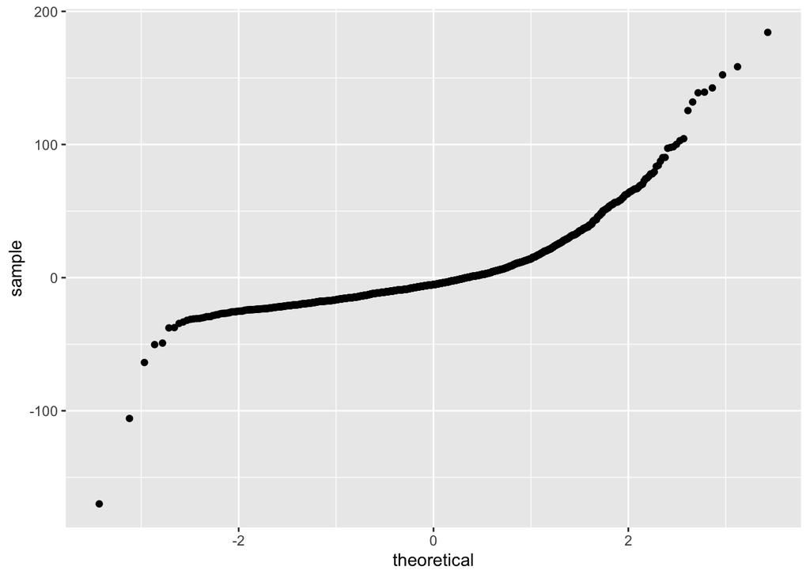

```r
ggplot(data = m_initial, aes(sample = .resid)) +
  stat_qq()
```

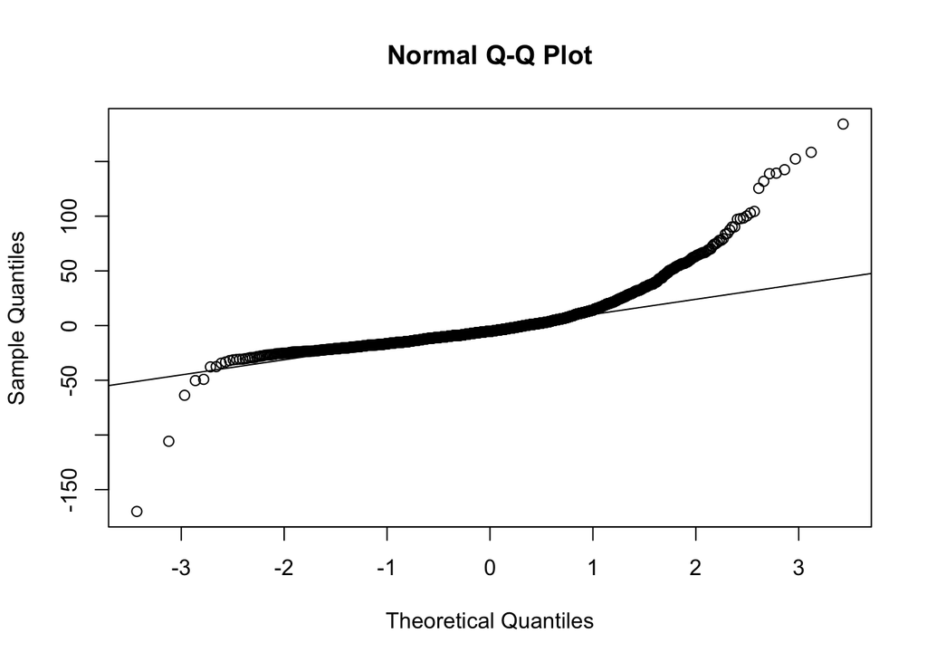

```r
qqnorm(m_initial$residuals)
qqline(m_initial$residuals)
```

I will replace the `win_shares` variable with the log-transformed `win_shares` variable see if there are any differences with the initial model:

```r
m_revised <- lm(log_win_shares ~ box_plus_minus + overall_pick
                + field_goal_percentage, data = new_df)
summary(m_revised)
```

```
##
## Call:
## lm(formula = log_win_shares ~ box_plus_minus + overall_pick +
##     field_goal_percentage, data = new_df)
##
## Residuals:
##      Min       1Q   Median       3Q      Max
## -11.9597  -0.7986  -0.0048   0.8275   8.3809
##
## Coefficients:
##                        Estimate Std. Error t value Pr(>|t|)
## (Intercept)            2.907331   0.206838  14.056   <2e-16 ***
## box_plus_minus         0.196156   0.009188  21.349   <2e-16 ***
## overall_pick          -0.030494   0.001868 -16.328   <2e-16 ***
## field_goal_percentage  0.557263   0.430395   1.295    0.196
## ---
## Signif. codes:  0 '***' 0.001 '**' 0.01 '*' 0.05 '.' 0.1 ' ' 1
##
## Residual standard error: 1.158 on 1648 degrees of freedom
##   (13 observations deleted due to missingness)
## Multiple R-squared:  0.4666, Adjusted R-squared:  0.4656
## F-statistic: 480.5 on 3 and 1648 DF,  p-value: < 2.2e-16
```

Using the log-transformed target variable, the Adjusted R-Square increased to 46.56%. However, `field_goal_percentage` has a p-value greater than 0.05. I removed the variable and re-ran the model:

```r
m_revised2 <- lm(log_win_shares ~ box_plus_minus + overall_pick, data = new_df)
summary(m_revised2)
```

```
##
## Call:
## lm(formula = log_win_shares ~ box_plus_minus + overall_pick,
##     data = new_df)
##
## Residuals:
##      Min       1Q   Median       3Q      Max
## -12.0281  -0.8093   0.0176   0.8215   8.4910
##
## Coefficients:
##                 Estimate Std. Error t value Pr(>|t|)
## (Intercept)     3.165260   0.055668   56.86   <2e-16 ***
## box_plus_minus  0.203290   0.007355   27.64   <2e-16 ***
## overall_pick   -0.030425   0.001867  -16.30   <2e-16 ***
## ---
## Signif. codes:  0 '***' 0.001 '**' 0.01 '*' 0.05 '.' 0.1 ' ' 1
##
## Residual standard error: 1.158 on 1649 degrees of freedom
##   (13 observations deleted due to missingness)
## Multiple R-squared:  0.466,  Adjusted R-squared:  0.4654
## F-statistic: 719.6 on 2 and 1649 DF,  p-value: < 2.2e-16
```

The new revised model without `field_goal_percentage` decreased the Adjusted R-Square slightly to 46.54%.

### Residual vs Fitted Values

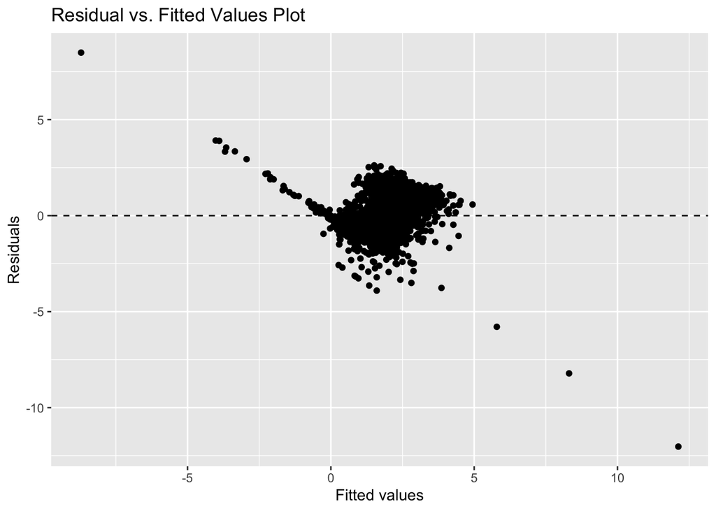

```r
ggplot(m_revised2, aes(x = .fitted, y = .resid)) +
  geom_point() +
  geom_hline(yintercept = 0, linetype = "dashed") +
  labs(title="Residual vs. Fitted Values Plot") +
  xlab("Fitted values") +
  ylab("Residuals")
```

### Near Normal Residuals Histogram

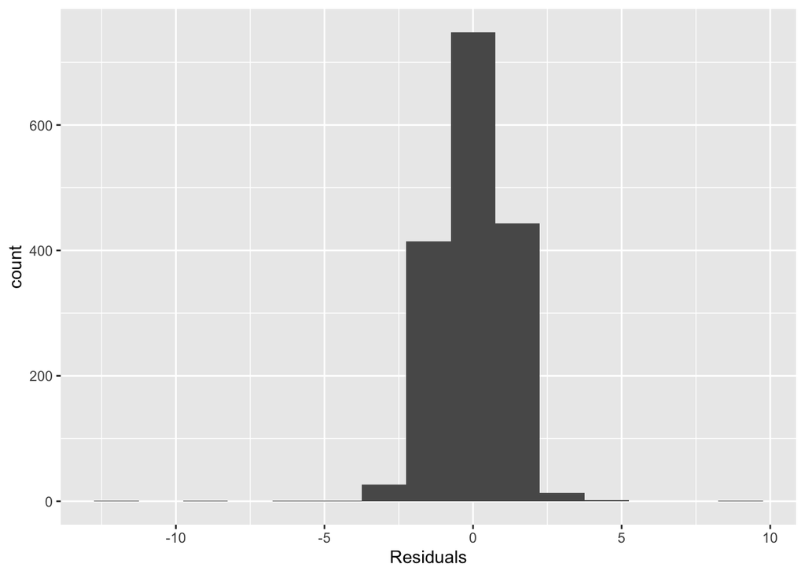

```r
ggplot(data = m_revised, aes(x = .resid)) +
  geom_histogram(binwidth = 1.5) +
  xlab("Residuals")
```